# What to do with all that code…?

2020.07.14

## This slide presentation

https://timathomas.github.io/git_tutorial/presentation/slideshow.html

## What *NOT* to do (a.k.a. my dissertation)

[figure not shown]

## A better git workflow

[figure not shown]

## Why git?

## Version control & collaboration

- Version control is like an *unlimited ‘undo’*.
- Version control also *allows teams to work in parallel*.
- Primarily used for *coding* (python, R, sql, ), *writing* (markdown, latex, etc.), and many *other formats*

## Reproducible code & public facing work

Git is a data scientists home for [projects](https://github.com/timathomas), but also

- Hosting [websites](https://evictions.study)
- Hosting [interactive maps](https://cci-ucb.github.io/sensitive_communities/map.html) and [code](https://github.com/cci-ucb/sensitive_communities)
- [Public facing documents](https://gitlab.com/timathomas/talks/-/tree/master/Presentation_PDFs)

## Work in parallel branches

- Your master is your primary working version (e.g. 1.0)
- When you want to make edits, you start a branch, make edits, then merge your work into the master

[figure not shown]

## *Caution:*

1. *When working with team members, don’t work in the master, just in your branch*.
- You can easily cause conflicts between versions.
1. *Don’t store data in a repo*
- Github repositories have about a 2gb limit and you can’t push files bigger than 100mb at a time.
- Instead, use Google Drive or Box
- If you convert a private repo to a public one, all the history and data will become public.

## Basic git principles

## Before git

- base version
- make some edits
- add more edits

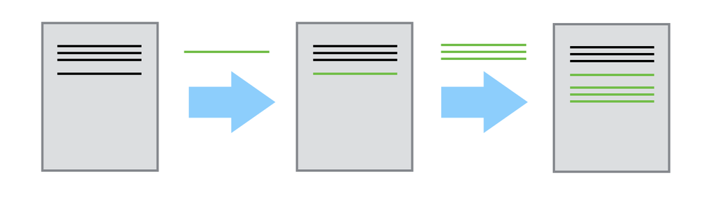

## Collaboration

Make **edits** in your branch, **commit** your edits to the repo, and **push** to your branch in Github

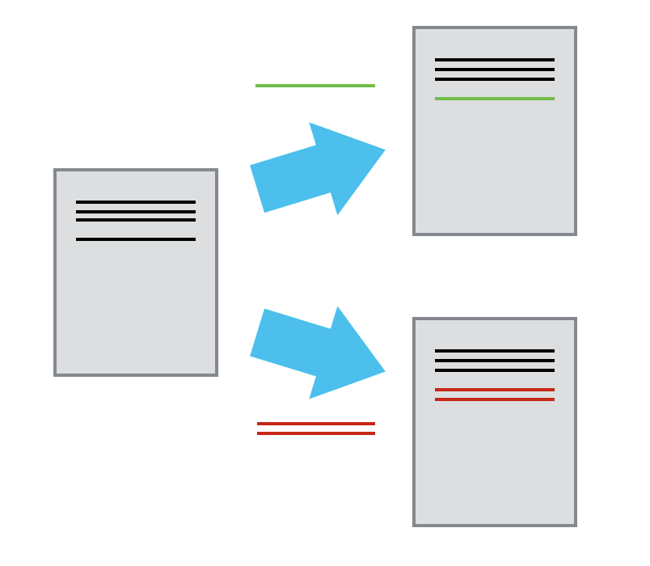

## Collaboration

Then, make a **pull request** to **merge** your edits into the master

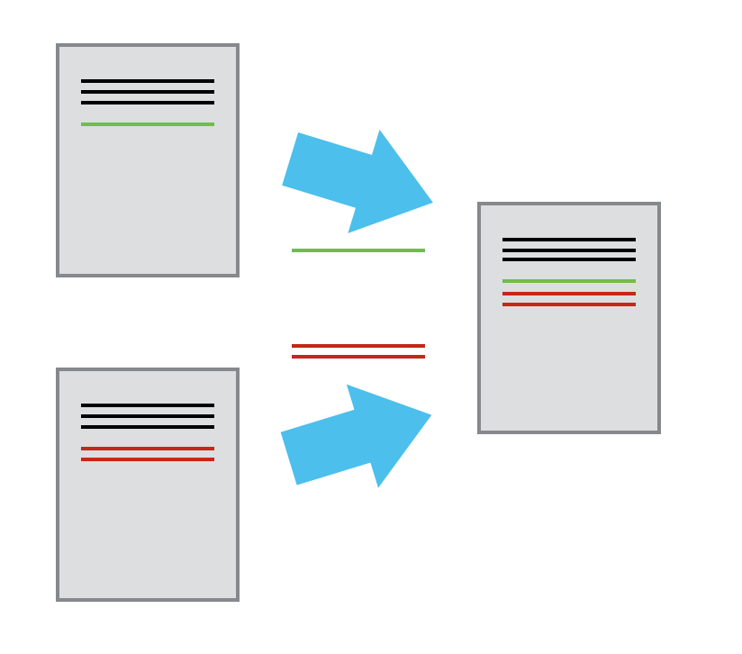

## git workflow summary

1. *edit* your file(s)
2. *commit* your changes (a.k.a. staging)
3. *push* to your branch on Github
4. *merge* your final edits into the master through a **pull request** on Github.com

## Activity 1

## Activity #1: Create a git repository on your local machine and push it to Github using [Github desktop](https://desktop.github.com)

1. Initialize a directory
2. Edit a file
3. Make a commit
4. Publish to github
5. Make a pull request (i.e. merge your edits to the master)

## Summary of what we just did

1. We made a repo
2. We made some edits
3. We staged the edits on our computer (add and commit edits)
4. We pushed the edits onto Github.com

## Add and Commit

[figure not shown]

## Push to Github.com

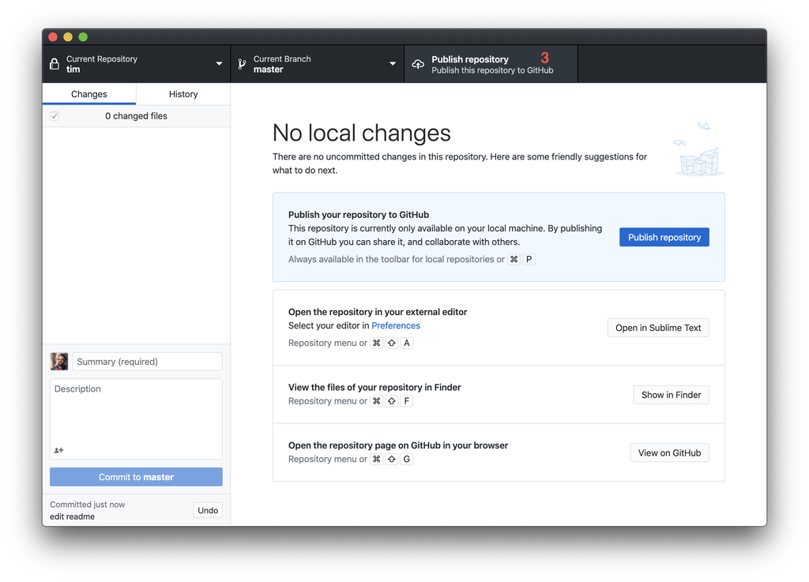

## Before we move on… some terminology

## git terms

- **head** = the tip of your current branch
  - e.g. the master branch or my “tim” branch
- **origin** = the online head of the respective branch
  - you’ll notice that Github Desktop says “fetch origin”
- **fetch** = tells your local git to retrieve the latest meta-data info from the original (yet doesn’t do any file transferring. It’s more like just checking to see if there are any changes available).
- **pull** = on the other hand does that AND brings (copy) those changes from the remote repository (i.e. it *merges* the online changes to your local branch)

## Activity 2

## Activity 2: Clone a Github repo, make some edits, and merge it into the master

1. Move your `Github` folder to your Home directory and rename it `git`
2. Clone the repo https://github.com/timathomas/git_tutorial
3. Make a branch
4. Edit a file in the `git_tutorial/code/` directory
5. Commit your edits
6. Publish to github
7. Make a pull request

## What you’ll be doing mostly during your projects

You’ll *work in the master* and *work on your own python notebook* (.ipynb)

1. Edit
2. Pull
3. Stage
4. Push

## How to deal with merge conflicts

https://help.github.com/en/github/collaborating-with-issues-and-pull-requests/resolving-a-merge-conflict-on-github

## Some resources

- [Github’s online tutorial](https://guides.github.com/activities/hello-world/)
- [Github Desktop Tutorial](https://help.github.com/en/desktop/getting-started-with-github-desktop/creating-your-first-repository-using-github-desktop)
- [A beginner’s guide to git and Github using the command line](https://towardsdatascience.com/getting-started-with-git-and-github-6fcd0f2d4ac6)
- [Software Carpentry](https://software-carpentry.org/lessons/)

## My favorite tools

- [Sublime Text](https://www.sublimetext.com)
  - Others [Atom](https://atom.io) (sluggish in my opinion)
  - Favorite Sublime Packages
    - Git, Gitgutter, Thesaurus, LanguageTool, R-IDE, SendCode, Terminal
- [Sublime Merge](https://www.sublimemerge.com) to view complex branches